# Tugas 1 MPDW

Gladys Adya Zafira

2023-09-03

Persiapan library

```r
library("forecast")
```

```r
library("graphics")
library("TTR")
library("TSA")
library("rio")
data<- import ("https://raw.githubusercontent.com/gladysadyaz/mpdw/main/Data/SPOT.csv")
data
```

```
##           Date   Open    High     Low  Close Adj Close   Volume
## 1   2021-01-01 317.42 332.600 305.510 331.36    331.36  3558100
## 2   2021-01-08 335.00 370.950 333.290 342.27    342.27  7400800
## 3   2021-01-15 330.72 350.250 317.010 348.30    348.30  6291200
## 4   2021-01-22 346.27 348.280 317.120 325.44    325.44  6376400
## 5   2021-01-29 328.59 350.250 310.700 314.70    314.70 13163700
## 6   2021-02-05 316.23 339.620 306.000 331.90    331.90  7916700
## 7   2021-02-12 333.94 364.000 329.395 354.88    354.88  5712600
## 8   2021-02-19 355.62 387.440 302.600 303.06    303.06 13905000
## 9   2021-02-26 300.00 326.150 278.230 285.01    285.01  9846200
## 10  2021-03-05 290.00 291.370 254.920 286.96    286.96 10305700
## 11  2021-03-12 280.06 292.660 266.145 271.73    271.73  5033600
## 12  2021-03-19 269.99 278.570 250.100 254.63    254.63  5447100
## 13  2021-03-26 258.51 280.000 249.000 273.10    273.10  6220700
## 14  2021-04-02 279.56 288.650 272.090 280.94    280.94  3599900
```

[output cut: 91 more lines]

```r
spot <- data[c("Date","Close")]
```

```r
View(spot)
str(spot)
```

```
## 'data.frame':    105 obs. of  2 variables:
##  $ Date : IDate, format: "2021-01-01" "2021-01-08" ...
##  $ Close: num  331 342 348 325 315 ...
```

```r
dim(spot)
```

```
## [1] 105   2
```

```r
data.ts <- ts(spot$Close)
data.ts
```

```
## Time Series:
## Start = 1
## End = 105
## Frequency = 1
##   [1] 331.36 342.27 348.30 325.44 314.70 331.90 354.88 303.06 285.01 286.96
##  [11] 271.73 254.63 273.10 280.94 299.74 265.16 262.15 237.04 217.07 228.68
##  [21] 240.26 232.19 247.19 247.11 264.16 268.63 256.15 247.97 244.18 225.27
##  [31] 221.13 215.04 205.08 224.62 254.03 246.01 242.02 234.86 225.34 234.90
##  [41] 247.37 255.00 288.95 293.48 276.65 263.37 249.49 228.54 233.42 226.55
##  [51] 236.63 237.92 228.27 226.45 208.66 171.32 159.76 167.83 159.22 149.21
##  [61] 139.92 132.67 138.73 149.26 151.02 141.39 136.27 112.62 102.68 105.59
##  [71]  97.08 105.77 108.62 116.50 111.93  97.85 102.19  93.83 105.83  96.32
##  [81] 115.62 114.59 122.40 122.73 114.39 113.53 106.52 105.18 103.96  92.45
##  [91]  86.84  92.25  82.65  87.74  81.74  71.72  78.44  79.45  78.26  79.45
## [101]  77.80  72.36  77.96  79.01  78.95
```

```r
summary(data.ts)
```

```
##    Min. 1st Qu.  Median    Mean 3rd Qu.    Max.
##   71.72  105.83  215.04  188.19  249.49  354.88
```

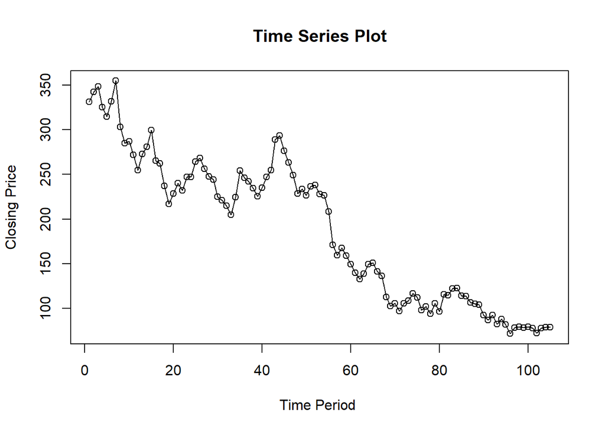

```r
ts.plot(data.ts, xlab="Time Period ", ylab="Closing Price",
        main = "Time Series Plot")
points(data.ts)
```

```r
#membagi data latih dan data uji
training_data <- spot[1:84,]
testing_data <- spot[85:105,]
train_data.ts <- ts(training_data$Close)
test_data.ts <- ts(testing_data$Close)
```

Eksplorasi Data

Eksplorasi data dilakukan pada keseluruhan data, data latih serta data uji menggunakan plot data deret waktu.

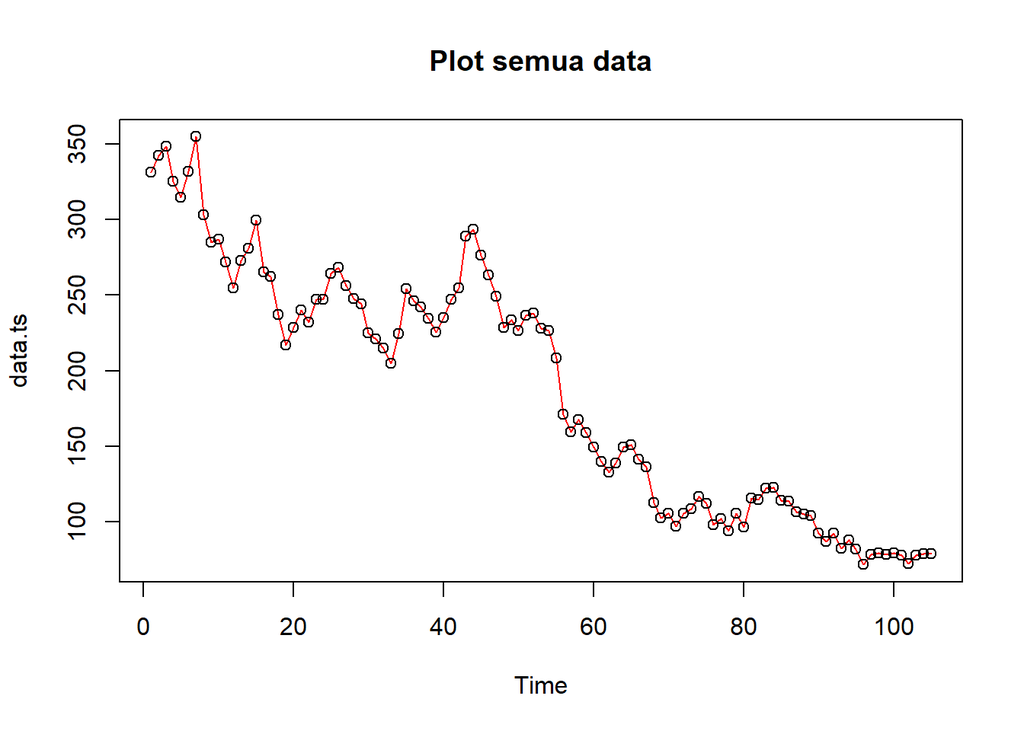

```r
#eksplorasi keseluruhan data
plot(data.ts, col="red",main="Plot semua data")
points(data.ts)
```

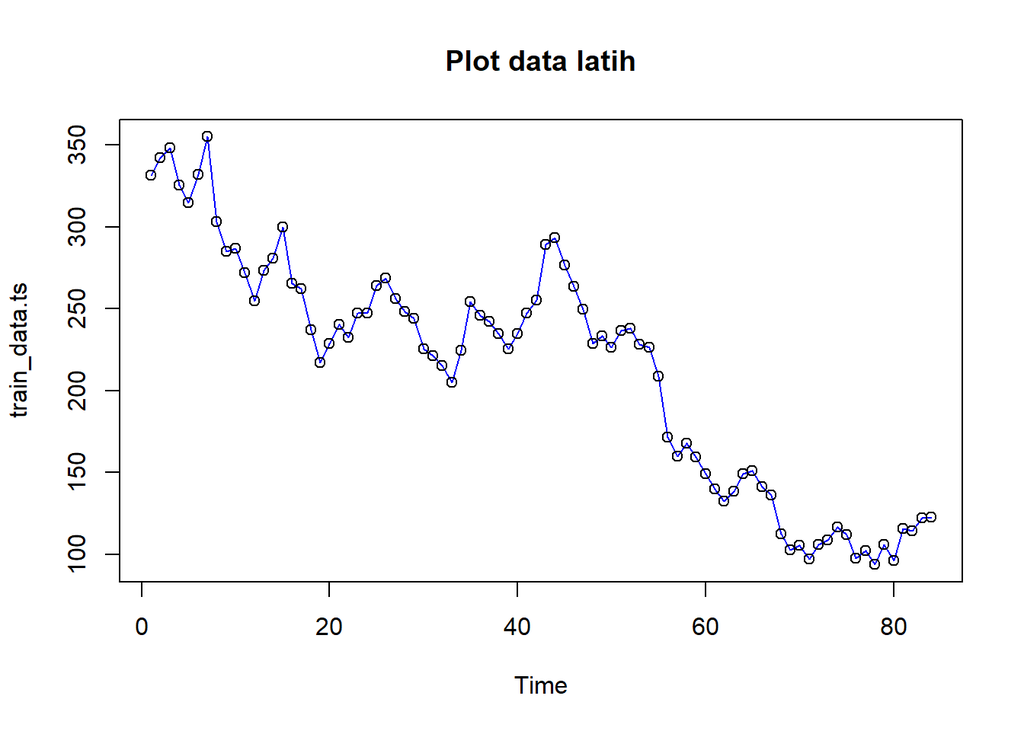

```r
#eksplorasi data latih
plot(train_data.ts, col="blue",main="Plot data latih")
points(train_data.ts)
```

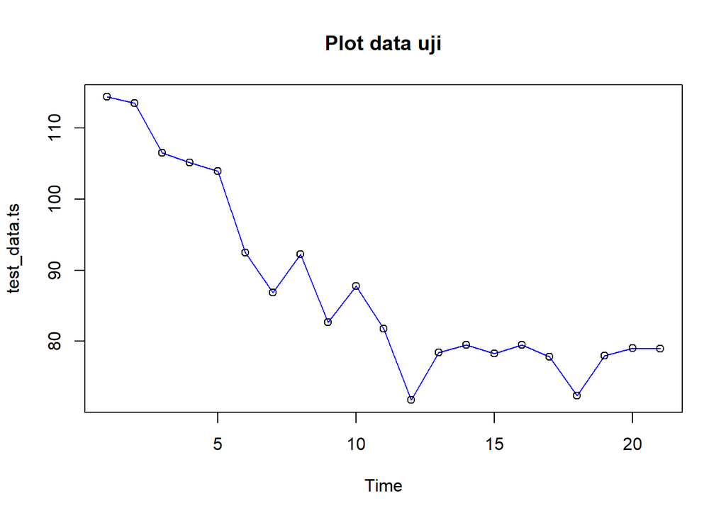

```r
#eksplorasi data uji
plot(test_data.ts, col="blue",main="Plot data uji")
points(test_data.ts)
```

Eksplorasi data juga dapat dilakukan menggunakan package ggplot2 dengan terlebih dahulu memanggil library package ggplot2.

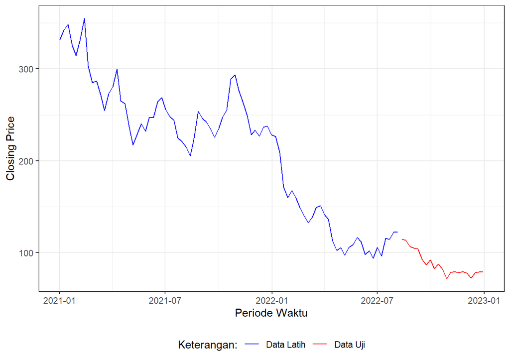

```r
#Eksplorasi dengan GGPLOT
library(ggplot2)
ggplot() +
  geom_line(data = training_data, aes(x = Date, y = Close, col = "Data Latih")) +
  geom_line(data = testing_data, aes(x = Date, y = Close, col = "Data Uji")) +
  labs(x = "Periode Waktu", y = "Closing Price", color = "Legend") +
  scale_colour_manual(name="Keterangan:", breaks = c("Data Latih", "Data Uji"),
                      values = c("blue", "red")) +
  theme_bw() + theme(legend.position = "bottom",
                     plot.caption = element_text(hjust=0.5, size=12))
```

### Double Moving Average (DMA)

Metode pemulusan Double Moving Average (DMA) pada dasarnya mirip dengan SMA. Namun demikian, metode ini lebih cocok digunakan untuk pola data trend. Proses pemulusan dengan rata rata dalam metode ini dilakukan sebanyak 2 kali.

```r
data.sma<-SMA(train_data.ts, n=4)
data.sma
```

```
## Time Series:
## Start = 1
## End = 84
## Frequency = 1
##  [1]       NA       NA       NA 336.8425 332.6775 330.0850 331.7300 326.1350
##  [9] 318.7125 307.4775 286.6900 274.5825 271.6050 270.1000 277.1025 279.7350
## [17] 276.9975 266.0225 245.3550 236.2350 230.7625 229.5500 237.0800 241.6875
## [25] 247.6625 256.7725 259.0125 259.2275 254.2325 243.3925 234.6375 226.4050
## [33] 216.6300 216.4675 224.6925 232.4350 241.6700 244.2300 237.0575 234.2800
## [41] 235.6175 240.6525 256.5550 271.2000 278.5200 280.6125 270.7475 254.5125
## [49] 243.7050 234.5000 231.2850 233.6300 232.3425 232.3175 225.3250 208.6750
## [57] 191.5475 176.8925 164.5325 159.0050 154.0450 145.2550 140.1325 140.1450
## [65] 142.9200 145.1000 144.4850 135.3250 123.2400 114.2900 104.4925 102.7800
## [73] 104.2650 106.9925 110.7050 108.7250 107.1175 101.4500  99.9250  99.5425
## [81] 102.9000 108.0900 112.2325 118.8350
```

```r
dma <- SMA(data.sma, n = 4)
At <- 2*data.sma - dma
Bt <- 2/(4-1)*(data.sma - dma)
data.dma<- At+Bt
data.ramal2<- c(NA, data.dma)

t = 1:21
f = c()

for (i in t) {
  f[i] = At[length(At)] + Bt[length(Bt)]*(i)
}

data.gab2 <- cbind(aktual = c(train_data.ts,rep(NA,21)), pemulusan1 = c(data.sma,rep(NA,21)),pemulusan2 = c(data.dma, rep(NA,21)),At = c(At, rep(NA,21)), Bt = c(Bt,rep(NA,21)),ramalan = c(data.ramal2, f[-1]))
data.gab2
```

```
##        aktual pemulusan1 pemulusan2        At           Bt   ramalan
##   [1,] 331.36         NA         NA        NA           NA        NA
##   [2,] 342.27         NA         NA        NA           NA        NA
##   [3,] 348.30         NA         NA        NA           NA        NA
##   [4,] 325.44   336.8425         NA        NA           NA        NA
##   [5,] 314.70   332.6775         NA        NA           NA        NA
##   [6,] 331.90   330.0850         NA        NA           NA        NA
##   [7,] 354.88   331.7300  329.89043 330.62626  -0.73582967        NA
##   [8,] 303.06   326.1350  319.43188 322.11313  -2.68124888 329.89043
##   [9,] 285.01   318.7125  305.45729 310.75938  -5.30208321 319.43188
##  [10,] 286.96   307.4775  284.91708 293.94125  -9.02416738 305.45729
##  [11,] 271.73   286.6900  248.25042 263.62625 -15.37583292 284.91708
##  [12,] 254.63   274.5825  237.44397 252.29938 -14.85541542 248.25042
##  [13,] 273.10   271.6050  249.13209 258.12125  -8.98916633 237.44397
##  [14,] 280.94   270.1000  260.69272 264.45563  -3.76291533 249.13209
```

[output cut: 91 more lines]

Hasil pemulusan menggunakan metode DMA divisualisasikan sebagai berikut

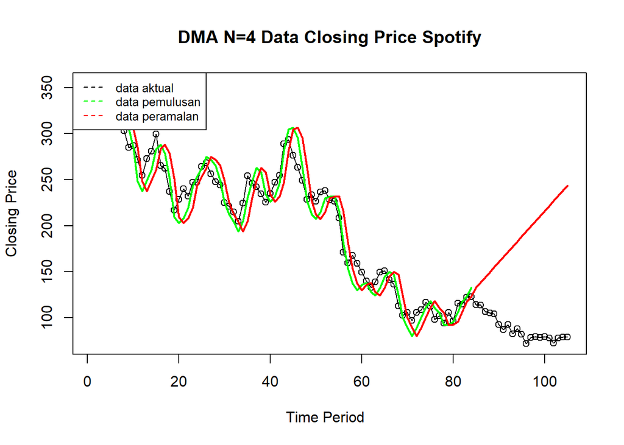

```r
ts.plot(data.ts, xlab="Time Period  ", ylab="Closing Price", main= "DMA N=4 Data Closing Price Spotify")
points(data.ts)
lines(data.gab2[,3],col="green",lwd=2)
lines(data.gab2[,6],col="red",lwd=2)
legend("topleft",c("data aktual","data pemulusan","data peramalan"), lty=8, col=c("black","green","red"), cex=0.8)
```

Selanjutnya perhitungan akurasi dilakukan baik pada data latih maupun data uji. Perhitungan akurasi dilakukan dengan ukuran akurasi SSE, MSE dan MAPE.

```r
#Menghitung nilai keakuratan data latih
error_train.dma = train_data.ts-data.ramal2[1:length(train_data.ts)]
SSE_train.dma = sum(error_train.dma[8:length(train_data.ts)]^2)
MSE_train.dma = mean(error_train.dma[8:length(train_data.ts)]^2)
MAPE_train.dma = mean(abs((error_train.dma[8:length(train_data.ts)]/train_data.ts[8:length(train_data.ts)])*100))

akurasi_train.dma <- matrix(c(SSE_train.dma, MSE_train.dma, MAPE_train.dma))
row.names(akurasi_train.dma)<- c("SSE", "MSE", "MAPE")
colnames(akurasi_train.dma) <- c("Akurasi m = 4")
akurasi_train.dma
```

```
##      Akurasi m = 4
## SSE   41326.702948
## MSE     536.710428
## MAPE      9.966751
```

Perhitungan akurasi pada data latih menggunakan nilai MAPE menghasilkan nilai MAPE yang kurang dari 10% sehingga dikategorikan sangat baik. Selanjutnya, perhitungan nilai akurasi dilakukan pada data uji.

```r
#Menghitung nilai keakuratan data uji
error_test.dma = test_data.ts-data.gab2[85:105,6]
SSE_test.dma = sum(error_test.dma^2)
MSE_test.dma = mean(error_test.dma^2)
MAPE_test.dma = mean(abs((error_test.dma/test_data.ts*100)))

akurasi_test.dma <- matrix(c(SSE_test.dma, MSE_test.dma, MAPE_test.dma))
row.names(akurasi_test.dma)<- c("SSE", "MSE", "MAPE")
colnames(akurasi_test.dma) <- c("Akurasi m = 2")
akurasi_test.dma
```

```
##      Akurasi m = 2
## SSE    255455.3672
## MSE     12164.5413
## MAPE      123.6233
```

### DES

Metode pemulusan *Double Exponential Smoothing* (DES) digunakan untuk data yang memiliki pola tren. Metode DES adalah metode semacam SES, hanya saja dilakukan dua kali, yaitu pertama untuk tahapan ‘level’ dan kedua untuk tahapan ‘tren’. Pemulusan menggunakan metode ini akan menghasilkan peramalan tidak konstan untuk periode berikutnya.

Pemulusan dengan metode DES kali ini akan menggunakan fungsi `HoltWinters()` . Jika sebelumnya nilai argumen `beta` dibuat `FALSE` , kali ini argumen tersebut akan diinisialisasi bersamaan dengan nilai `alpha` .

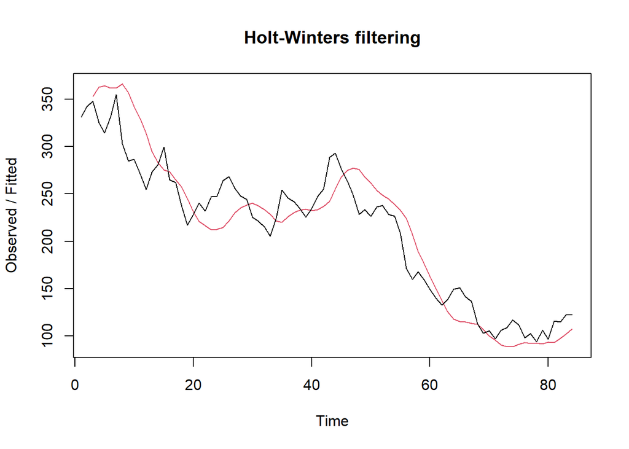

```r
#Lamda=0.2 dan gamma=0.2
des.1<- HoltWinters(train_data.ts, gamma = FALSE, beta = 0.2, alpha = 0.2)
plot(des.1)
```

```r
#ramalan
ramalandes1<- forecast(des.1, h=21)
ramalandes1
```

```
##     Point Forecast    Lo 80    Hi 80       Lo 95    Hi 95
##  85       112.7809 77.24038 148.3213  58.4263877 167.1353
##  86       114.9834 78.43368 151.5331  59.0854305 170.8814
##  87       117.1859 79.30572 155.0662  59.2531421 175.1187
##  88       119.3885 79.83781 158.9391  58.9009525 179.8760
##  89       121.5910 80.02232 163.1597  58.0171820 185.1648
##  90       123.7935 79.86114 167.7259  56.6047302 190.9824
##  91       125.9961 79.36350 172.6287  54.6777080 197.3145
##  92       128.1986 78.54359 177.8536  52.2578108 204.1394
##  93       130.4012 77.41841 183.3839  49.3710468 211.4313
##  94       132.6037 76.00610 189.2013  46.0451503 219.1622
##  95       134.8062 74.32472 195.2877  42.3077509 227.3047
##  96       137.0088 72.39152 201.6260  38.1852140 235.8323
##  97       139.2113 70.22248 208.2001  33.7019991 244.7206
##  98       141.4138 67.83217 214.9955  28.8803832 253.9473
##  99       143.6164 65.23370 221.9990  23.7404177 263.4923
## 100       145.8189 62.43879 229.1990  18.3000234 273.3378
## 101       148.0214 59.45788 236.5850  12.5751571 283.4677
## 102       150.2240 56.30024 244.1477   6.5800081 293.8680
## 103       152.4265 52.97412 251.8789   0.3271995 304.5258
## 104       154.6291 49.48688 259.7712  -6.1720209 315.4301
## 105       156.8316 45.84510 267.8181 -12.9076050 326.5708
```

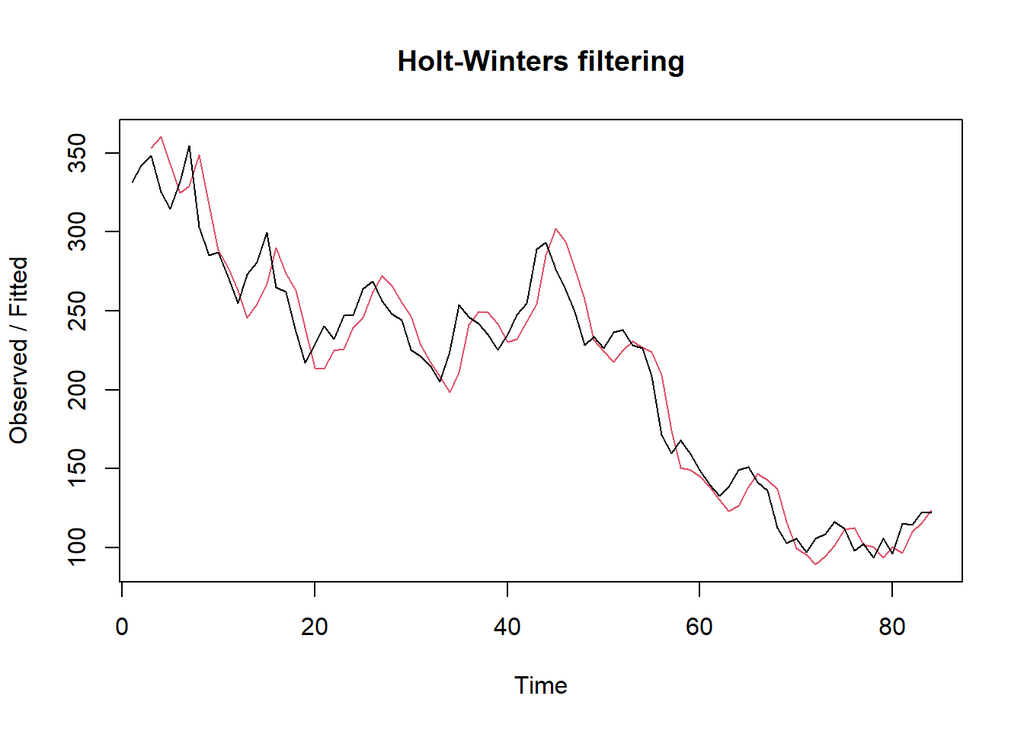

```r
#Lamda=0.6 dan gamma=0.3
des.2<- HoltWinters(train_data.ts, gamma = FALSE, beta = 0.3, alpha = 0.6)
plot(des.2)
```

```r
#ramalan
ramalandes2<- forecast(des.2, h=21)
ramalandes2
```

```
##     Point Forecast      Lo 80    Hi 80       Lo 95    Hi 95
##  85       127.0555 103.329562 150.7814   90.769806 163.3412
##  86       130.9564 100.866486 161.0463   84.937863 176.9749
##  87       134.8572  97.118813 172.5957   77.141298 192.5732
##  88       138.7581  92.327940 185.1883   67.749297 209.7669
##  89       142.6590  86.653679 198.6643   57.006269 228.3117
##  90       146.5598  80.203498 212.9162   45.076574 248.0431
##  91       150.4607  73.053013 227.8684   32.075859 268.8455
##  92       154.3616  65.258090 243.4650   18.089558 290.6336
##  93       158.2624  56.861845 259.6630    3.183616 313.3412
##  94       162.1633  47.898797 276.4278  -12.589176 336.9158
##  95       166.0642  38.397419 293.7309  -29.185273 361.3136
##  96       169.9650  28.381764 311.5483  -46.567890 386.4980
##  97       173.8659  17.872550 329.8592  -64.705339 412.4371
##  98       177.7668   6.887908 348.6456  -83.569894 439.1034
##  99       181.6676  -4.556096 367.8914 -103.136981 466.4722
## 100       185.5685 -16.445067 387.5821 -123.384586 494.5216
## 101       189.4694 -28.765995 407.7047 -144.292814 523.2315
## 102       193.3702 -41.507034 428.2475 -165.843544 552.5840
## 103       197.2711 -54.657324 449.1995 -188.020171 582.5624
## 104       201.1720 -68.206857 470.5508 -210.807387 613.1513
## 105       205.0728 -82.146364 492.2920 -234.191018 644.3367
```

Selanjutnya jika ingin membandingkan plot data latih dan data uji adalah sebagai berikut.

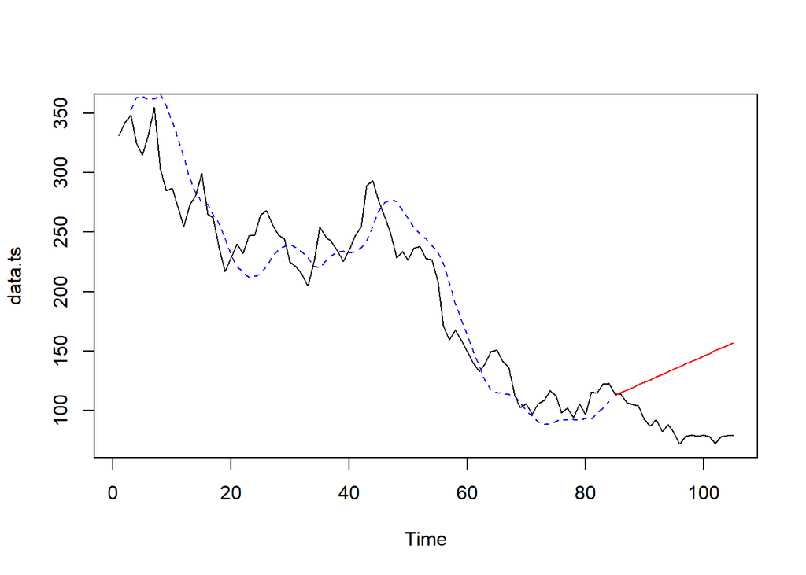

```r
#Visually evaluate the prediction
plot(data.ts)
lines(des.1$fitted[,1], lty=2, col="blue")
lines(ramalandes1$mean, col="red")
```

Untuk mendapatkan nilai parameter optimum dari DES, argumen `alpha` dan `beta` dapat dibuat `NULL` seperti berikut.

```r
#Lamda dan gamma optimum
des.opt<- HoltWinters(train_data.ts, gamma = FALSE)
des.opt
```

```
## Holt-Winters exponential smoothing with trend and without seasonal component.
##
## Call:
## HoltWinters(x = train_data.ts, gamma = FALSE)
##
## Smoothing parameters:
##  alpha: 1
##  beta : 0.1005122
##  gamma: FALSE
##
## Coefficients:
##          [,1]
## a 122.7300030
## b   0.2815509
```

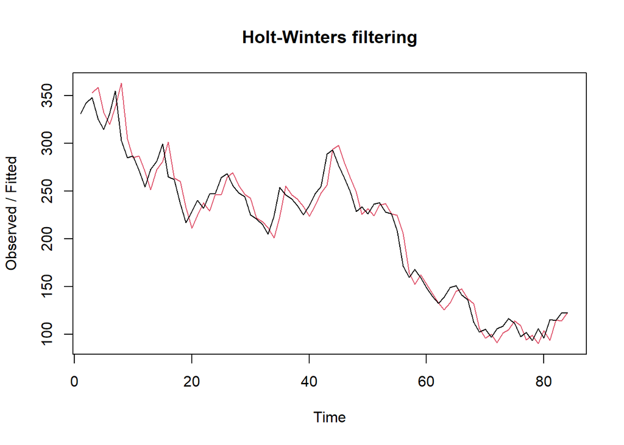

```r
plot(des.opt)
```

```r
#ramalan
ramalandesopt<- forecast(des.opt, h=21)
ramalandesopt
```

```
##     Point Forecast      Lo 80    Hi 80       Lo 95    Hi 95
##  85       123.0116 102.826130 143.1970   92.140611 153.8825
##  86       123.2931  93.277664 153.3085   77.388449 169.1978
##  87       123.5747  84.991515 162.1578   64.566833 182.5825
##  88       123.8562  77.177729 170.5347   52.467636 195.2448
##  89       124.1378  69.549994 178.7255   40.652978 207.6225
##  90       124.4193  61.971551 186.8671   28.913705 219.9249
##  91       124.7009  54.367308 195.0344   17.134975 232.2667
##  92       124.9824  46.692470 203.2724    5.248278 244.7165
##  93       125.2640  38.918874 211.6090   -6.789455 257.3174
##  94       125.5455  31.028216 220.0628  -19.006218 270.0972
##  95       125.8271  23.008374 228.6458  -31.420552 283.0747
##  96       126.1086  14.851266 237.3660  -44.044816 296.2620
##  97       126.3902   6.551541 246.2288  -56.887195 309.6675
##  98       126.6717  -1.894263 255.2377  -69.952982 323.2964
##  99       126.9533 -10.488267 264.3948  -83.245421 337.1520
## 100       127.2348 -19.231635 273.7013  -96.766291 351.2359
## 101       127.5164 -28.124830 283.1576 -110.516304 365.5490
## 102       127.7979 -37.167808 292.7636 -124.495390 380.0912
## 103       128.0795 -46.360147 302.5191 -138.702902 394.8618
## 104       128.3610 -55.701146 312.4232 -153.137772 409.8598
## 105       128.6426 -65.189904 322.4750 -167.798618 425.0838
```

Selanjutnya akan dilakukan perhitungan akurasi pada data latih maupun data uji dengan ukuran akurasi SSE, MSE dan MAPE.

#### Akurasi Data Latih

```r
#Akurasi Data Training
ssedes.train1<-des.1$SSE
msedes.train1<-ssedes.train1/length(train_data.ts)
sisaandes1<-ramalandes1$residuals
head(sisaandes1)
```

```
## Time Series:
## Start = 1
## End = 6
## Frequency = 1
## [1]         NA         NA  -4.880005 -37.478794 -49.938677 -29.969065
```

```r
mapedes.train1 <- sum(abs(sisaandes1[3:length(train_data.ts)]/train_data.ts[3:length(train_data.ts)])
                      *100)/length(train_data.ts)

akurasides.1 <- matrix(c(ssedes.train1,msedes.train1,mapedes.train1))
row.names(akurasides.1)<- c("SSE", "MSE", "MAPE")
colnames(akurasides.1) <- c("Akurasi lamda=0.2 dan gamma=0.2")
akurasides.1
```

```
##      Akurasi lamda=0.2 dan gamma=0.2
## SSE                      62873.78992
## MSE                        748.49750
## MAPE                        10.51159
```

```r
ssedes.train2<-des.2$SSE
msedes.train2<-ssedes.train2/length(train_data.ts)
sisaandes2<-ramalandes2$residuals
head(sisaandes2)
```

```
## Time Series:
## Start = 1
## End = 6
## Frequency = 1
## [1]         NA         NA  -4.880005 -34.843591 -28.437183   7.184045
```

```r
mapedes.train2 <- sum(abs(sisaandes2[3:length(train_data.ts)]/train_data.ts[3:length(train_data.ts)])
                      *100)/length(train_data.ts)

akurasides.2 <- matrix(c(ssedes.train2,msedes.train2,mapedes.train2))
row.names(akurasides.2)<- c("SSE", "MSE", "MAPE")
colnames(akurasides.2) <- c("Akurasi lamda=0.6 dan gamma=0.3")
akurasides.2
```

```
##      Akurasi lamda=0.6 dan gamma=0.3
## SSE                     27781.073151
## MSE                       330.727061
## MAPE                        7.051804
```

#### Akurasi Data Uji

```r
#Akurasi Data Testing
selisihdes1<-ramalandes1$mean-testing_data$Close
selisihdes1
```

```
## Time Series:
## Start = 85
## End = 105
## Frequency = 1
##  [1] -1.609138  1.453398 10.665937 14.208470 17.631008 31.343546 39.156084
##  [8] 35.948616 47.751151 44.863691 53.066227 65.288761 60.771296 61.963838
## [15] 65.356369 66.368911 70.221441 77.863980 74.466518 75.619051 77.881593
```

```r
SSEtestingdes1<-sum(selisihdes1^2)
MSEtestingdes1<-SSEtestingdes1/length(testing_data$Close)
MAPEtestingdes1<-sum(abs(selisihdes1/testing_data$Close)*100)/length(testing_data$Close)

selisihdes2<-ramalandes2$mean-testing_data$Close
selisihdes2
```

```
## Time Series:
## Start = 85
## End = 105
## Frequency = 1
##  [1]  12.66551  17.42637  28.33724  33.57810  38.69897  54.10984  63.62070
##  [8]  62.11157  75.61243  74.42330  84.32417  98.24503  95.42589  98.31676
## [15] 103.40763 106.11850 111.66936 121.01022 119.31109 122.16195 126.12283
```

```r
SSEtestingdes2<-sum(selisihdes2^2)
MSEtestingdes2<-SSEtestingdes2/length(testing_data$Close)
MAPEtestingdes2<-sum(abs(selisihdes2/testing_data$Close)*100)/length(testing_data$Close)

selisihdesopt<-ramalandesopt$mean-testing_data$Close
selisihdesopt
```

```
## Time Series:
## Start = 85
## End = 105
## Frequency = 1
##  [1]  8.621555  9.763106 17.054659 18.676207 20.177759 31.969312 37.860864
##  [8] 32.732411 42.613959 37.805514 44.087065 54.388613 47.950163 47.221719
## [15] 48.693265 47.784821 49.716366 55.437919 50.119472 49.351020 49.692576
```

```r
SSEtestingdesopt<-sum(selisihdesopt^2)
MSEtestingdesopt<-SSEtestingdesopt/length(testing_data$Close)
MAPEtestingdesopt<-sum(abs(selisihdesopt/testing_data$Close)*100)/length(testing_data$Close)

akurasitestingdes <-
  matrix(c(SSEtestingdes1,MSEtestingdes1,MAPEtestingdes1,SSEtestingdes2,MSEtestingdes2,
           MAPEtestingdes2,SSEtestingdesopt,MSEtestingdesopt,MAPEtestingdesopt),
         nrow=3,ncol=3)
row.names(akurasitestingdes)<- c("SSE", "MSE", "MAPE")
colnames(akurasitestingdes) <- c("des ske1","des ske2","des opt")
akurasitestingdes
```

```
##         des ske1     des ske2     des opt
## SSE  60342.53755 155649.95193 35035.79183
## MSE   2873.45417   7411.90247  1668.37104
## MAPE    58.86874     96.52493    46.69194
```